# wrangling

```python
import pandas as pd
import matplotlib.pyplot as plt
import numpy as np
import os
import statsmodels.api as sm
import statsmodels.formula.api as smf
import seaborn as sns
```

```python
os.getcwd()
os.chdir("/Users/bvelasq6/Box Sync/CEE Educational Analytics/ATOG Analysis")
os.getcwd()
```

```
'/Users/bvelasq6/Box Sync/CEE Educational Analytics/ATOG Analysis'
```

Import relevant files

```python
admissions = pd.read_csv("Data/admissions.csv",low_memory=False)
courses = pd.read_csv("Data/courses.csv",low_memory = False)
ap_tests = pd.read_csv("Data/ap_tests.csv",low_memory= False)
students = pd.read_csv("/Users/bvelasq6/Box Sync/CEE Core Data/students.csv",low_memory=False)
students = students[students.PIDM.isin (admissions["PIDM"])]
```

```python
list(students)
student_subset = ["PIDM","ADMIT_LEVEL","GENDER","ETHN_CODE",
                  "IS_URM","FIRST_TERM_GPA","FIRST_TERM_MAJOR_1",
                  "FIRST_TERM_MAJOR_2",
                  "FIRST_TERM_MAJOR_3",
                  "ANY_FIRST_TERM_MAJOR_IS_STEM",
                  'NUM_MAJOR_CHANGES',
 'NUM_WLD_MAT_RMED',
 'NUM_WLD_MAT_PREP',
 'NUM_WLD_MAT_CONC',
 'NUM_WLD_CHE_PREP',
 'NUM_WLD_CHE_CONC',
 'NUM_WLD_PHY_PREP',
 'NUM_WLD_PHY_CONC',
 'NUM_WLD_ENGLISH',
 'NUM_STEM_CRSE',
'STARTED_INTERNATIONAL',
                   'FIRST_GENERATION',
 'LOW_INCOME',
                   'TRIPLE',
                   'NO_TRIPLE',
                    'NUM_TERM_NOT_GS',
 'FIRST_TERM_NOT_GS'
]
students = students[student_subset]
```

In the cell below, I figure out what the unique AP tests are named.

```python
test_sub = ["APST","APMA","APBI","APMB","APCH","APPM","APCA","APP1","APPB","APPC","APP2"]
ap_tests_unique = ap_tests[ap_tests.TEST.isin (test_sub)].groupby(['TEST','DESCRIPTION']).size().reset_index().rename(columns={0:'count'})
ap_test_sub = ap_tests[ap_tests.TEST.isin (test_sub)]
ap_test_sub = ap_test_sub.groupby(['PIDM','TEST'],as_index=False)['SCORE'].max()
ap_test_sub = ap_test_sub.pivot(index='PIDM',columns='TEST',values='SCORE')
ap_test_sub = ap_test_sub.rename(columns={"APBI": "AP_Bio",
                            "APCA": "AP_CS",
                            "APCH":"AP_Chemistry",
                            "APMA":"AP_Calculus_AB",
                            "APMB":"AP_Calculus_BC",
                            "APP1": "AP_Physics_1",
                           "APP2": "AP_Physics_2",
                           "APPB": "AP_Physics_B",
                           "APPC": "AP_Physics_C_EM",
                           "APPM": "AP_Physics_C_Mech",
                           "APST": "AP_Stats"})
```

Make sure we have all the AP tests.

```python
#ap_test_sub.head(n=3)
# ap_tests_unique
ap_test_sub.describe()
#ap_tests.drop_duplicates(['TEST','DESCRIPTION'])[['TEST','DESCRIPTION']]
```

| TEST | AP_Bio | AP_CS | AP_Chemistry | AP_Calculus_AB | AP_Calculus_BC | AP_Physics_1 | AP_Physics_2 | AP_Physics_B | AP_Physics_C_EM | AP_Physics_C_Mech | AP_Stats |
| --- | --- | --- | --- | --- | --- | --- | --- | --- | --- | --- | --- |
| count | 393.000000 | 43.000000 | 588.000000 | 395.000000 | 173.000000 | 132.000000 | 22.000000 | 10.000000 | 13.000000 | 39.000000 | 106.000000 |
| mean | 3.587786 | 3.906977 | 3.602041 | 4.298734 | 4.375723 | 3.613636 | 3.727273 | 3.900000 | 4.461538 | 4.205128 | 3.811321 |
| std | 0.653135 | 0.781145 | 0.715939 | 0.807247 | 0.809026 | 0.727305 | 0.702500 | 0.994429 | 0.776250 | 0.695076 | 0.769826 |
| min | 3.000000 | 3.000000 | 3.000000 | 3.000000 | 3.000000 | 3.000000 | 3.000000 | 3.000000 | 3.000000 | 3.000000 | 3.000000 |
| 25% | 3.000000 | 3.000000 | 3.000000 | 4.000000 | 4.000000 | 3.000000 | 3.000000 | 3.000000 | 4.000000 | 4.000000 | 3.000000 |
| 50% | 3.000000 | 4.000000 | 3.000000 | 5.000000 | 5.000000 | 3.000000 | 4.000000 | 3.500000 | 5.000000 | 4.000000 | 4.000000 |
| 75% | 4.000000 | 4.500000 | 4.000000 | 5.000000 | 5.000000 | 4.000000 | 4.000000 | 5.000000 | 5.000000 | 5.000000 | 4.000000 |
| max | 5.000000 | 5.000000 | 5.000000 | 5.000000 | 5.000000 | 5.000000 | 5.000000 | 5.000000 | 5.000000 | 5.000000 | 5.000000 |

Now, PIVOT the DF so that there is one row per student only take their max score.

```python
# ap_test_sub = pd.get_dummies(ap_test_sub, sparse=True, columns =['AP_Bio',
#  'AP_CS',
#  'AP_Chemistry',
#  'AP_Calculus_AB',
#  'AP_Calculus_BC',
#  'AP_Physics_1',
#  'AP_Physics_2',
#  'AP_Physics_B',
#  'AP_Physics_C_EM',
#  'AP_Physics_C_Mech',
#  'AP_Stats'])
# ap_test_sub.head(3)
# ap_test_sub.columns.isin(['AP_Bio',
#  'AP_CS',
#  'AP_Chemistry',
#  'AP_Calculus_AB',
#  'AP_Calculus_BC',
#  'AP_Physics_1',
#  'AP_Physics_2',
#  'AP_Physics_B',
#  'AP_Physics_C_EM',
#  'AP_Physics_C_Mech.',
#  'AP_Stats'])
```

```python
#ap_test_sub.head(n=3)
list(ap_test_sub)
```

```
['AP_Bio',
 'AP_CS',
 'AP_Chemistry',
 'AP_Calculus_AB',
 'AP_Calculus_BC',
 'AP_Physics_1',
 'AP_Physics_2',
 'AP_Physics_B',
 'AP_Physics_C_EM',
 'AP_Physics_C_Mech',
 'AP_Stats']
```

```python
# ap_test_sub['no_AP_Bio_1'] = np.where(
#     (ap_test_sub['AP_Bio_3.0'] == 0 ) &
#     (ap_test_sub['AP_Bio_4.0'] == 0 ) &
#     (ap_test_sub['AP_Bio_5.0'] == 0 ),
#                                     1, 0)

# ap_test_sub['no_AP_CS'] = np.where(
#     (ap_test_sub['AP_CS_3.0'] == 0 ) &
#     (ap_test_sub['AP_CS_4.0'] == 0 ) &
#     (ap_test_sub['AP_CS_5.0'] == 0 ),
#                                     1, 0)

# ap_test_sub['no_AP_Chemistry'] = np.where(
#     (ap_test_sub['AP_Chemistry_3.0'] == 0 ) &
#     (ap_test_sub['AP_Chemistry_4.0'] == 0 ) &
#     (ap_test_sub['AP_Chemistry_5.0'] == 0 ),
#                                     1, 0)

# ap_test_sub['no_AP_Calculus_AB'] = np.where(
#     (ap_test_sub['AP_Calculus_AB_3.0'] == 0 ) &
#     (ap_test_sub['AP_Calculus_AB_4.0'] == 0 ) &
#     (ap_test_sub['AP_Calculus_AB_5.0'] == 0 ),
#                                     1, 0)

# ap_test_sub['no_AP_Calculus_BC'] = np.where(
#     (ap_test_sub['AP_Calculus_BC_3.0'] == 0 ) &
#     (ap_test_sub['AP_Calculus_BC_4.0'] == 0 ) &
#     (ap_test_sub['AP_Calculus_BC_5.0'] == 0 ),
#                                     1, 0)

# ap_test_sub['no_AP_Physics_1'] = np.where(
#     (ap_test_sub['AP_Physics_1_3.0'] == 0 ) &
#     (ap_test_sub['AP_Physics_1_4.0'] == 0 ) &
#     (ap_test_sub['AP_Physics_1_5.0'] == 0 ),
#                                     1, 0)

# ap_test_sub['no_AP_Physics_2'] = np.where(
#     (ap_test_sub['AP_Physics_2_3.0'] == 0 ) &
#     (ap_test_sub['AP_Physics_2_4.0'] == 0 ) &
#     (ap_test_sub['AP_Physics_2_5.0'] == 0 ),
#                                     1, 0)

# ap_test_sub['no_AP_Physics_B'] = np.where(
#     (ap_test_sub['AP_Physics_B_3.0'] == 0 ) &
#     (ap_test_sub['AP_Physics_B_4.0'] == 0 ) &
#     (ap_test_sub['AP_Physics_B_5.0'] == 0 ),
#                                     1, 0)


# ap_test_sub['no_AP_Physics_C_EM'] = np.where(
#     (ap_test_sub['AP_Physics_C_EM_3.0'] == 0 ) &
#     (ap_test_sub['AP_Physics_C_EM_4.0'] == 0 ) &
#     (ap_test_sub['AP_Physics_C_EM_5.0'] == 0 ),
#                                     1, 0)

# ap_test_sub['no_AP_Physics_C_EM'] = np.where(
#     (ap_test_sub['AP_Physics_C_EM_3.0'] == 0 ) &
#     (ap_test_sub['AP_Physics_C_EM_4.0'] == 0 ) &
#     (ap_test_sub['AP_Physics_C_EM_5.0'] == 0 ),
#                                     1, 0)

# ap_test_sub['no_AP_Stats_1'] = np.where(
#     (ap_test_sub['AP_Stats_3.0'] == 0 ) &
#     (ap_test_sub['AP_Stats_4.0'] == 0 ) &
#     (ap_test_sub['AP_Stats_5.0'] == 0 ),
#                                     1, 0)
```

```python
ap_test_sub.head(3)
```

| TEST PIDM | AP_Bio | AP_CS | AP_Chemistry | AP_Calculus_AB | AP_Calculus_BC | AP_Physics_1 | AP_Physics_2 | AP_Physics_B | AP_Physics_C_EM | AP_Physics_C_Mech | AP_Stats |
| --- | --- | --- | --- | --- | --- | --- | --- | --- | --- | --- | --- |
| 2455146 | NaN | NaN | NaN | 5.0 | NaN | NaN | NaN | NaN | NaN | NaN | NaN |
| 3000386 | NaN | NaN | NaN | 5.0 | NaN | NaN | NaN | 3.0 | NaN | NaN | NaN |
| 3035218 | NaN | NaN | NaN | 3.0 | NaN | NaN | NaN | 3.0 | NaN | NaN | NaN |

Next, we begin merging on admissions and courses data.

```python
courses['CLASS'] = courses.SUBJ + '_' + courses.CRSE
```

```python
courses.head(n=3)
```

|  | PIDM | TERM | CRN | COLL | DEPT | DDESCR | SUBJ | CRSE | SECTN | UNITS | ... | BILLABLE_UNITS | GRADING_TYPE_CODE | GRADING_TYPE_DESC | COURSE_TYPE_CODE | COURSE_TYPE_DESC | REPEATED | SUBJ_DESC | IC_TYPE | EA_COUNTRY | CLASS |
| --- | --- | --- | --- | --- | --- | --- | --- | --- | --- | --- | --- | --- | --- | --- | --- | --- | --- | --- | --- | --- | --- |
| 0 | 3342800 | 202003 | 56178 | BI | BIS | Biological Sciences | BIS | 002A | A06 | NaN | ... | 5 | N | Normal/Letter Grading | NaN | NaN | NaN | Biological Sciences | NaN | NaN | BIS_002A |
| 1 | 3393921 | 202003 | 70545 | LS | MAT | Mathematics | MAT | 016A | 001 | NaN | ... | 3 | N | Normal/Letter Grading | NaN | NaN | NaN | Mathematics | NaN | NaN | MAT_016A |
| 2 | 3427129 | 202003 | 70545 | LS | MAT | Mathematics | MAT | 016A | 001 | NaN | ... | 3 | N | Normal/Letter Grading | NaN | NaN | NaN | Mathematics | NaN | NaN | MAT_016A |

3 rows × 43 columns

Check to see if we have the correct classes

```python
# courses_unique = courses.groupby(['GRADE']).size().reset_index().rename(columns={0:'count'})
# courses_unique
```

```python
#courses_wide = courses.groupby(['PIDM','CLASS','GRADE_PT'],as_index=False)['TERM'].min()

#courses_wide = courses[courses['TERM'] == courses.groupby(['PIDM','CLASS'])['TERM'].transform('min')]
#courses_wide = courses_wide.dropduplicates("PIDM")
#courses_wide.apply(pd.DataFrame)
#courses_wide = courses_wide.sort_values(['PIDM', 'TERM'], inplace=True, ascending=True)
#courses_wide.drop_duplicates(['PIDM', 'TERM'], inplace=True)
```

```python
#courses_wide = pd.DataFrame(np.sort(courses_wide[['PIDM','CLASS']], axis=1))
#courses_wide = courses_wide.sort_values(by=['PIDM','CLASS'], ascending=False)
courses_wide = courses.drop_duplicates(['PIDM','CLASS'], keep ='last')

courses_wide_grade = courses_wide.pivot(index="PIDM",columns="CLASS",values="GRADE")
courses_wide_units = courses_wide.pivot(index="PIDM",columns="CLASS",values="BILLABLE_UNITS")
courses_wide = courses_wide.pivot(index="PIDM",columns="CLASS",values="GRADE_PT")

courses_wide.head(n=3)
courses_wide_grade.head(n=3)
#count_class = courses_wide.groupby(["PIDM", "CLASS",]).size()
#count_class = count_class[count_class>1]
#count_class
#courses_wide.GRADE_PT
courses_wide = courses_wide.rename(columns={"BIS_002A": "bis2a_grade_pt",
                             "CHE_002A": "chem2a_grade_pt",
                             "MAT_016A": "mat16a_grade_pt",
                             "MAT_021A": "mat21a_grade_pt"
                            })

courses_wide_grade = courses_wide_grade.rename(columns={"BIS_002A": "bis2a_grade",
                             "CHE_002A": "chem2a_grade",
                             "MAT_016A": "mat16a_grade",
                             "MAT_021A": "mat21a_grade"
                            })

courses_wide_units = courses_wide_units.rename(columns={"BIS_002A": "bis2a_units",
                             "CHE_002A": "chem2a_units",
                             "MAT_016A": "mat16a_units",
                             "MAT_021A": "mat21a_units"
                            })
```

Now we will begin merging admissions+ap_test+first term grades, etc.

```python
main_file = courses_wide.merge(courses_wide_grade, on="PIDM", how= 'outer' )
main_file = main_file.merge(courses_wide_units,on="PIDM",how='outer')
main_file = admissions.merge(main_file, on='PIDM',how='outer')
main_file = main_file.merge(students, on='PIDM', how='left')
main_file = main_file.merge(ap_test_sub, on='PIDM',how = 'left')
main_file.head(n=3)
```

|  | PIDM | TERM | ENROLL | CRAP | CRAPOLD | ADMIT_LEVEL_x | APPCAT | HSCODE | HSDESC | LSTYPE | ... | AP_CS | AP_Chemistry | AP_Calculus_AB | AP_Calculus_BC | AP_Physics_1 | AP_Physics_2 | AP_Physics_B | AP_Physics_C_EM | AP_Physics_C_Mech | AP_Stats |
| --- | --- | --- | --- | --- | --- | --- | --- | --- | --- | --- | --- | --- | --- | --- | --- | --- | --- | --- | --- | --- | --- |
| 0 | 3134058 | 201610 | Y | NaN | NaN | H | HC | 50365.0 | BRAWLEY UNION HIGH SCHOOL | 1 | ... | NaN | NaN | NaN | NaN | NaN | NaN | NaN | NaN | NaN | NaN |
| 1 | 3083988 | 201610 | Y | NaN | NaN | H | HC | 53125.0 | ARROYO HIGH SCHOOL | 1 | ... | NaN | NaN | NaN | NaN | NaN | NaN | NaN | NaN | NaN | NaN |
| 2 | 3090990 | 201610 | Y | NaN | NaN | H | HC | 50011.0 | ALAMEDA COMMUNITY LEARNING CTR | 1 | ... | NaN | NaN | NaN | NaN | NaN | NaN | NaN | NaN | NaN | NaN |

3 rows × 201 columns

Now make booleans if a student took any of the AP courses we are interested in.

```python
# ['AP_Bio',
#  'AP_CS',
#  'AP_Chemistry',
#  'AP_Calculus_AB',
#  'AP_Calculus_BC',
#  'AP_Physics_1',
#  'AP_Physics_2',
#  'AP_Physics_B',
#  'AP_Physics_C_EM',
#  'AP_Physics_C_Mech',
#  'AP_Stats']

main_file['AP_Bio_bool'] = np.where(
    main_file['AP_Bio'].isna(),0, 1)

main_file['AP_CS_bool'] = np.where(
    main_file['AP_CS'].isna(),0, 1)

main_file['AP_Chemistry_bool'] = np.where(
    main_file['AP_Chemistry'].isna(),0, 1)

main_file['AP_Calculus_AB_bool'] = np.where(
    main_file['AP_Calculus_AB'].isna(),0, 1)

main_file['AP_Calculus_BC_bool'] = np.where(
    main_file['AP_Calculus_BC'].isna(),0, 1)

main_file['AP_Physics_1_bool'] = np.where(
    main_file['AP_Physics_1'].isna(),0, 1)

main_file['AP_Physics_2_bool'] = np.where(
    main_file['AP_Physics_2'].isna(),0, 1)

main_file['AP_Physics_B_bool'] = np.where(
    main_file['AP_Physics_B'].isna(),0, 1)

main_file['AP_Physics_C_EM_bool'] = np.where(
    main_file['AP_Physics_C_EM'].isna(),0, 1)

main_file['AP_Physics_C_Mech_bool'] = np.where(
    main_file['AP_Physics_C_Mech'].isna(),0, 1)


main_file['AP_Stats_bool'] = np.where(
    main_file['AP_Stats'].isna(),0, 1)
```

```python
main_file['AP_Physics_bool'] = main_file['AP_Physics_1_bool']  | main_file['AP_Physics_2_bool'] | main_file['AP_Physics_B_bool'] | main_file['AP_Physics_C_EM_bool'] | main_file['AP_Physics_C_Mech']

#f1['ops_on'] = (df1['Feed'] > 10) & (df1['Pressure'] > 10) & (df1['Temp'] > 10)
```

Now check to see if we have all the correct columns.

```python
main_file = pd.get_dummies(main_file, columns=['SEX'])
main_file.to_csv("Data/clean_file.csv",index=False)
```

Now begin looking for correlations, etc.

```python
corr_matrix=main_file.corr()
pd.options.display.max_rows=132
mat21_corr_matrix = corr_matrix["mat21a_grade_pt"].sort_values(ascending=False)
mat16_corr_matrix = corr_matrix["mat16a_grade_pt"].sort_values(ascending=False)
bis2a_corr_matrix = corr_matrix["bis2a_grade_pt"].sort_values(ascending=False)
chem2a_corr_matrix = corr_matrix["chem2a_grade_pt"].sort_values(ascending=False)
```

Ok. Lets select the columns that ought to be relevant for our analyis. I'm thinking of the usual suspects

```python
controls = [
'ATOG',
'ATOGA',
'ATOGB',
'ATOGC',
'ATOGD',
'ATOGE',
'ATOGF',
'ATOGG',
'APTAKEN',
'APPASSED',
'APCREDIT',
'GPA',
'LOWINCOME',
#'FG',
#'UNWEIGHTED_GPA',
'SAT_TOTAL_OFFICIAL',
'IS_URM',
'ANY_FIRST_TERM_MAJOR_IS_STEM',
'STARTED_INTERNATIONAL',
'FIRST_GENERATION',
'LOW_INCOME',
'TRIPLE',
'NO_TRIPLE',
# 'AP_Bio',
#  'AP_CS',
#  'AP_Chemistry',
#  'AP_Calculus_AB',
#  'AP_Calculus_BC',
#  'AP_Physics_1',
#  'AP_Physics_2',
#  'AP_Physics_B',
#  'AP_Physics_C_EM',
#  'AP_Physics_C_Mech',
#  'AP_Stats',
 'AP_Bio_bool',
 'AP_CS_bool',
 'AP_Chemistry_bool',
 'AP_Calculus_AB_bool',
 'AP_Calculus_BC_bool',
#  'AP_Physics_1_bool',
#  'AP_Physics_2_bool',
#  'AP_Physics_B_bool',
#  'AP_AP_Physics_C_EM_bool',
#  'AP_Physics_C_Mech_bool',
'AP_Physics_bool',
 'AP_Stats_bool',
 'SEX_F']
```

Now lets make some models. I'm thinking: 'bis2a_grade_pt'b~usuals+ap_scores+ 'chem2a_grade_pt' 'mat16a_grade_pt' 'mat21a_grade_pt'

Ok. I need to create some other boolean variables. Namely, if they took an AP course, and if they recieved a 4 or 5 in a given test. Do this for all the AP tests.

Side note: It seems that Sci Kit Learn is more for machine learning project, in particular predicting outcomes of unseen data. For this study it is better to look use the statsmodel package.

It seems that if there are a lot of NA there are some problems. If I choose to drop NAs, it drops the WHOLE column? According to a SE thread that is what happens here: https://stackoverflow.com/questions/45545774/multiple-ols-regression-with-statsmodel-valueerror-zero-size-array-to-reduction

```python
#main_file= sm.add_constant(main_file, prepend=False)
X=main_file[controls]
X = sm.add_constant(X, prepend=False)
```

```python
np.asarray(X)
```

```
array([[46.0, 8, 8, ..., 0, 1, 1.0],
       [42.0, 5, 8, ..., 0, 1, 1.0],
       [47.0, 5, 8, ..., 0, 1, 1.0],
       ...,
       [50.0, 6, 8, ..., 0, 0, 1.0],
       [72.0, 14, 10, ..., 0, 1, 1.0],
       [48.0, 4, 8, ..., 0, 0, 1.0]], dtype=object)
```

```python
# 'bis2a_grade_pt',
#  'chem2a_grade_pt',
#  'mat16a_grade_pt',
#  'mat21a_grade_pt',

#For bis2a
y_bis=main_file['bis2a_grade_pt']
mod_bis = sm.OLS(y_bis, X.astype(float), missing='drop',hasconst=True)    # Describe model
res_bis = mod_bis.fit()       # Fit model
print(res_bis.summary())   # Summarize model
```

```
                            OLS Regression Results
==============================================================================
Dep. Variable:         bis2a_grade_pt   R-squared:                       0.262
Model:                            OLS   Adj. R-squared:                  0.253
Method:                 Least Squares   F-statistic:                     29.92
Date:                Mon, 20 Apr 2020   Prob (F-statistic):          3.94e-129
Time:                        08:08:23   Log-Likelihood:                -2745.7
No. Observations:                2305   AIC:                             5547.
Df Residuals:                    2277   BIC:                             5708.
Df Model:                          27
Covariance Type:            nonrobust
================================================================================================
                                   coef    std err          t      P>|t|      [0.025      0.975]
------------------------------------------------------------------------------------------------
ATOG                             0.0011      0.006      0.200      0.841      -0.010       0.012
ATOGA                           -0.0258      0.010     -2.511      0.012      -0.046      -0.006
ATOGB                            0.0017      0.013      0.137      0.891      -0.023       0.026
ATOGC                           -0.0066      0.010     -0.686      0.493      -0.026       0.012
ATOGD                            0.0274      0.008      3.292      0.001       0.011       0.044
ATOGE                           -0.0042      0.009     -0.451      0.652      -0.022       0.014
ATOGF                           -0.0021      0.007     -0.292      0.770      -0.016       0.012
ATOGG                           -0.0118      0.007     -1.702      0.089      -0.025       0.002
APTAKEN                          0.0499      0.017      2.860      0.004       0.016       0.084
APPASSED                         0.0499      0.017      2.860      0.004       0.016       0.084
APCREDIT                        -0.0090      0.005     -1.686      0.092      -0.019       0.001
GPA                              0.8002      0.088      9.111      0.000       0.628       0.972
LOWINCOME                        0.0358      0.033      1.084      0.279      -0.029       0.100
SAT_TOTAL_OFFICIAL               0.0019      0.000     10.473      0.000       0.002       0.002
IS_URM                          -0.1289      0.073     -1.767      0.077      -0.272       0.014
ANY_FIRST_TERM_MAJOR_IS_STEM     0.1909      0.049      3.930      0.000       0.096       0.286
STARTED_INTERNATIONAL            0.2110      0.077      2.724      0.007       0.059       0.363
FIRST_GENERATION                -0.0210      0.065     -0.323      0.747      -0.149       0.107
LOW_INCOME                       0.0358      0.033      1.084      0.279      -0.029       0.100
TRIPLE                          -0.1803      0.100     -1.798      0.072      -0.377       0.016
NO_TRIPLE                       -0.0254      0.085     -0.299      0.765      -0.192       0.142
AP_Bio_bool                      0.0920      0.080      1.146      0.252      -0.065       0.250
AP_CS_bool                       0.0648      0.313      0.207      0.836      -0.550       0.679
AP_Chemistry_bool                0.0490      0.069      0.713      0.476      -0.086       0.184
AP_Calculus_AB_bool              0.0170      0.082      0.206      0.837      -0.144       0.178
AP_Calculus_BC_bool             -0.2038      0.132     -1.541      0.123      -0.463       0.055
AP_Physics_bool                 -0.3774      0.162     -2.325      0.020      -0.696      -0.059
AP_Stats_bool                   -0.1815      0.159     -1.145      0.252      -0.492       0.129
SEX_F                           -0.0180      0.037     -0.485      0.627      -0.091       0.055
const                           -3.1067      0.449     -6.916      0.000      -3.988      -2.226
==============================================================================
Omnibus:                      236.383   Durbin-Watson:                   1.984
Prob(Omnibus):                  0.000   Jarque-Bera (JB):              351.452
Skew:                          -0.766   Prob(JB):                     4.82e-77
Kurtosis:                       4.147   Cond. No.                     1.02e+16
==============================================================================

Warnings:
[1] Standard Errors assume that the covariance matrix of the errors is correctly specified.
[2] The smallest eigenvalue is 3.78e-23. This might indicate that there are
strong multicollinearity problems or that the design matrix is singular.
```

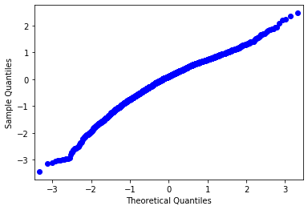

```python
residuals_bis = res_bis.resid # residuals
fig = sm.qqplot(residuals_bis)
plt.show()
```

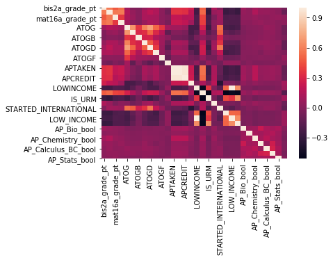

```python
sns.heatmap(main_file[[
    'bis2a_grade_pt',
#  'chem2a_grade_pt',
#  'mat16a_grade_pt',
#  'mat21a_grade_pt',
'ATOG',
'ATOGA',
'ATOGB',
'ATOGC',
'ATOGD',
'ATOGE',
'ATOGF',
'ATOGG',
'APTAKEN',
'APPASSED',
'APCREDIT',
'GPA',
'LOWINCOME',
#'FG',
#'UNWEIGHTED_GPA',
'SAT_TOTAL_OFFICIAL',
'IS_URM',
'ANY_FIRST_TERM_MAJOR_IS_STEM',
'STARTED_INTERNATIONAL',
'FIRST_GENERATION',
'LOW_INCOME',
'TRIPLE',
#'NO_TRIPLE',
# 'AP_Bio',
#  'AP_CS',
#  'AP_Chemistry',
#  'AP_Calculus_AB',
#  'AP_Calculus_BC',
#  'AP_Physics_1',
#  'AP_Physics_2',
#  'AP_Physics_B',
#  'AP_Physics_C_EM',
#  'AP_Physics_C_Mech',
#  'AP_Stats',
 'AP_Bio_bool',
 'AP_CS_bool',
 'AP_Chemistry_bool',
 'AP_Calculus_AB_bool',
 'AP_Calculus_BC_bool',
#  'AP_Physics_1_bool',
#  'AP_Physics_2_bool',
#  'AP_Physics_B_bool',
#  'AP_AP_Physics_C_EM_bool',
 'AP_Physics_bool',
 'AP_Stats_bool',
 'SEX_F']].corr())
```

```python
#For chem2a
y_chem=main_file['chem2a_grade_pt']
mod_chem = sm.OLS(y_chem, X.astype(float),missing='drop',hasconst=True)    # Describe model
res_chem = mod_chem.fit()       # Fit model
print(res_chem.summary())   # Summarize model
```

```
                            OLS Regression Results
==============================================================================
Dep. Variable:        chem2a_grade_pt   R-squared:                       0.337
Model:                            OLS   Adj. R-squared:                  0.330
Method:                 Least Squares   F-statistic:                     52.25
Date:                Mon, 20 Apr 2020   Prob (F-statistic):          1.77e-232
Time:                        08:08:23   Log-Likelihood:                -3143.0
No. Observations:                2910   AIC:                             6344.
Df Residuals:                    2881   BIC:                             6517.
Df Model:                          28
Covariance Type:            nonrobust
================================================================================================
                                   coef    std err          t      P>|t|      [0.025      0.975]
------------------------------------------------------------------------------------------------
ATOG                             0.0050      0.004      1.154      0.249      -0.003       0.013
ATOGA                           -0.0218      0.008     -2.848      0.004      -0.037      -0.007
ATOGB                            0.0044      0.010      0.453      0.650      -0.015       0.024
ATOGC                            0.0058      0.008      0.772      0.440      -0.009       0.020
ATOGD                            0.0238      0.006      3.736      0.000       0.011       0.036
ATOGE                           -0.0080      0.007     -1.153      0.249      -0.022       0.006
ATOGF                           -0.0053      0.006     -0.944      0.345      -0.016       0.006
ATOGG                           -0.0200      0.005     -3.690      0.000      -0.031      -0.009
APTAKEN                         -0.4340      0.718     -0.604      0.546      -1.842       0.974
APPASSED                         0.5007      0.719      0.696      0.486      -0.909       1.911
APCREDIT                        -0.0060      0.004     -1.433      0.152      -0.014       0.002
GPA                              0.7294      0.069     10.630      0.000       0.595       0.864
LOWINCOME                        0.0034      0.027      0.126      0.899      -0.049       0.055
SAT_TOTAL_OFFICIAL               0.0021      0.000     14.275      0.000       0.002       0.002
IS_URM                          -0.1710      0.058     -2.941      0.003      -0.285      -0.057
ANY_FIRST_TERM_MAJOR_IS_STEM     0.0265      0.040      0.661      0.509      -0.052       0.105
STARTED_INTERNATIONAL            0.2888      0.057      5.063      0.000       0.177       0.401
FIRST_GENERATION                -0.0039      0.052     -0.075      0.940      -0.106       0.099
LOW_INCOME                       0.0034      0.027      0.126      0.899      -0.049       0.055
TRIPLE                          -0.0743      0.079     -0.938      0.348      -0.230       0.081
NO_TRIPLE                       -0.0378      0.068     -0.554      0.579      -0.171       0.096
AP_Bio_bool                     -0.0699      0.068     -1.028      0.304      -0.203       0.063
AP_CS_bool                       0.2801      0.210      1.335      0.182      -0.131       0.691
AP_Chemistry_bool                0.4227      0.058      7.346      0.000       0.310       0.536
AP_Calculus_AB_bool              0.0274      0.067      0.407      0.684      -0.105       0.159
AP_Calculus_BC_bool              0.0433      0.111      0.390      0.696      -0.174       0.261
AP_Physics_bool                  0.0621      0.114      0.544      0.586      -0.162       0.286
AP_Stats_bool                   -0.0065      0.126     -0.052      0.959      -0.253       0.240
SEX_F                           -0.0479      0.028     -1.700      0.089      -0.103       0.007
const                           -3.2446      0.355     -9.148      0.000      -3.940      -2.549
==============================================================================
Omnibus:                      190.886   Durbin-Watson:                   2.009
Prob(Omnibus):                  0.000   Jarque-Bera (JB):              285.199
Skew:                          -0.542   Prob(JB):                     1.17e-62
Kurtosis:                       4.085   Cond. No.                     1.02e+16
==============================================================================

Warnings:
[1] Standard Errors assume that the covariance matrix of the errors is correctly specified.
[2] The smallest eigenvalue is 4.71e-23. This might indicate that there are
strong multicollinearity problems or that the design matrix is singular.
```

```python
residuals_chem = res_chem.resid # residuals
fig = sm.qqplot(residuals_chem)
plt.show()
```

[output not shown]

```python
sns.heatmap(main_file[[
    'bis2a_grade_pt',
#  'chem2a_grade_pt',
#  'mat16a_grade_pt',
#  'mat21a_grade_pt',
'ATOG',
'ATOGA',
'ATOGB',
'ATOGC',
'ATOGD',
'ATOGE',
'ATOGF',
'ATOGG',
'APTAKEN',
'APPASSED',
'APCREDIT',
'GPA',
'LOWINCOME',
#'FG',
#'UNWEIGHTED_GPA',
'SAT_TOTAL_OFFICIAL',
'IS_URM',
'ANY_FIRST_TERM_MAJOR_IS_STEM',
'STARTED_INTERNATIONAL',
'FIRST_GENERATION',
'LOW_INCOME',
'TRIPLE',
#'NO_TRIPLE',
# 'AP_Bio',
#  'AP_CS',
#  'AP_Chemistry',
#  'AP_Calculus_AB',
#  'AP_Calculus_BC',
#  'AP_Physics_1',
#  'AP_Physics_2',
#  'AP_Physics_B',
#  'AP_Physics_C_EM',
#  'AP_Physics_C_Mech',
#  'AP_Stats',
 'AP_Bio_bool',
 'AP_CS_bool',
 'AP_Chemistry_bool',
 'AP_Calculus_AB_bool',
 'AP_Calculus_BC_bool',
#  'AP_Physics_1_bool',
#  'AP_Physics_2_bool',
#  'AP_Physics_B_bool',
#  'AP_AP_Physics_C_EM_bool',
 'AP_Physics_bool',
 'AP_Stats_bool',
 'SEX_F']].corr())
```

[output not shown]

```python
#For mat16a
y_mat16 = main_file['mat16a_grade_pt']
mod_mat16 = sm.OLS(y_mat16, X.astype(float),missing='drop',hasconst=True)    # Describe model
res_mat16 = mod_mat16.fit()       # Fit model
print(res_mat16.summary())   # Summarize model
```

```
                            OLS Regression Results
==============================================================================
Dep. Variable:        mat16a_grade_pt   R-squared:                       0.271
Model:                            OLS   Adj. R-squared:                  0.244
Method:                 Least Squares   F-statistic:                     10.05
Date:                Mon, 20 Apr 2020   Prob (F-statistic):           5.76e-35
Time:                        08:08:23   Log-Likelihood:                -917.85
No. Observations:                 758   AIC:                             1892.
Df Residuals:                     730   BIC:                             2021.
Df Model:                          27
Covariance Type:            nonrobust
================================================================================================
                                   coef    std err          t      P>|t|      [0.025      0.975]
------------------------------------------------------------------------------------------------
ATOG                            -0.0023      0.010     -0.231      0.817      -0.022       0.018
ATOGA                           -0.0104      0.018     -0.574      0.566      -0.046       0.025
ATOGB                            0.0013      0.025      0.053      0.958      -0.048       0.051
ATOGC                            0.0244      0.016      1.565      0.118      -0.006       0.055
ATOGD                            0.0066      0.015      0.445      0.657      -0.023       0.036
ATOGE                            0.0100      0.014      0.703      0.482      -0.018       0.038
ATOGF                        -2.608e-05      0.013     -0.002      0.998      -0.026       0.026
ATOGG                           -0.0116      0.014     -0.833      0.405      -0.039       0.016
APTAKEN                          0.1195      0.034      3.566      0.000       0.054       0.185
APPASSED                         0.1195      0.034      3.566      0.000       0.054       0.185
APCREDIT                        -0.0343      0.011     -3.254      0.001      -0.055      -0.014
GPA                              1.0680      0.149      7.160      0.000       0.775       1.361
LOWINCOME                        0.0311      0.061      0.506      0.613      -0.089       0.152
SAT_TOTAL_OFFICIAL               0.0021      0.000      6.261      0.000       0.001       0.003
IS_URM                          -0.2826      0.126     -2.250      0.025      -0.529      -0.036
ANY_FIRST_TERM_MAJOR_IS_STEM    -0.0939      0.065     -1.456      0.146      -0.221       0.033
STARTED_INTERNATIONAL            0.3079      0.135      2.287      0.022       0.044       0.572
FIRST_GENERATION                -0.1030      0.115     -0.895      0.371      -0.329       0.123
LOW_INCOME                       0.0311      0.061      0.506      0.613      -0.089       0.152
TRIPLE                           0.1849      0.166      1.114      0.266      -0.141       0.511
NO_TRIPLE                       -0.1349      0.159     -0.850      0.396      -0.446       0.177
AP_Bio_bool                     -0.0756      0.196     -0.385      0.700      -0.460       0.309
AP_CS_bool                       1.3465      1.348      0.999      0.318      -1.301       3.994
AP_Chemistry_bool                0.3370      0.234      1.442      0.150      -0.122       0.796
AP_Calculus_AB_bool              0.4191      0.306      1.370      0.171      -0.181       1.019
AP_Calculus_BC_bool             -0.1281      0.861     -0.149      0.882      -1.818       1.561
AP_Physics_bool                 -1.2946      0.899     -1.439      0.151      -3.060       0.471
AP_Stats_bool                    0.0983      0.601      0.164      0.870      -1.081       1.278
SEX_F                            0.1900      0.071      2.680      0.008       0.051       0.329
const                           -4.2250      0.780     -5.416      0.000      -5.756      -2.694
==============================================================================
Omnibus:                       50.200   Durbin-Watson:                   1.876
Prob(Omnibus):                  0.000   Jarque-Bera (JB):               58.619
Skew:                          -0.649   Prob(JB):                     1.87e-13
Kurtosis:                       3.414   Cond. No.                     1.02e+16
==============================================================================

Warnings:
[1] Standard Errors assume that the covariance matrix of the errors is correctly specified.
[2] The smallest eigenvalue is 1.13e-23. This might indicate that there are
strong multicollinearity problems or that the design matrix is singular.
```

```python
residuals_mat16 = res_mat16.resid # residuals
fig = sm.qqplot(residuals_mat16)
plt.show()
```

[output not shown]

```python
sns.heatmap(main_file[[
#     'bis2a_grade_pt',
#  'chem2a_grade_pt',
 'mat16a_grade_pt',
#  'mat21a_grade_pt',
'ATOG',
'ATOGA',
'ATOGB',
'ATOGC',
'ATOGD',
'ATOGE',
'ATOGF',
'ATOGG',
'APTAKEN',
'APPASSED',
'APCREDIT',
'GPA',
'LOWINCOME',
#'FG',
#'UNWEIGHTED_GPA',
'SAT_TOTAL_OFFICIAL',
'IS_URM',
'ANY_FIRST_TERM_MAJOR_IS_STEM',
'STARTED_INTERNATIONAL',
'FIRST_GENERATION',
'LOW_INCOME',
'TRIPLE',
#'NO_TRIPLE',
# 'AP_Bio',
#  'AP_CS',
#  'AP_Chemistry',
#  'AP_Calculus_AB',
#  'AP_Calculus_BC',
#  'AP_Physics_1',
#  'AP_Physics_2',
#  'AP_Physics_B',
#  'AP_Physics_C_EM',
#  'AP_Physics_C_Mech',
#  'AP_Stats',
 'AP_Bio_bool',
 'AP_CS_bool',
 'AP_Chemistry_bool',
 'AP_Calculus_AB_bool',
 'AP_Calculus_BC_bool',
#  'AP_Physics_1_bool',
#  'AP_Physics_2_bool',
#  'AP_Physics_B_bool',
#  'AP_AP_Physics_C_EM_bool',
 'AP_Physics_bool',
 'AP_Stats_bool',
 'SEX_F']].corr())
```

[output not shown]

```python
#For mat21
y_mat21 = main_file['mat21a_grade_pt']
mod_mat21 = sm.OLS(y_mat21, X.astype(float),missing='drop',hasconst=True)    # Describe model
res_mat21 = mod_mat21.fit()       # Fit model
print(res_mat21.summary())   # Summarize model
```

```
                            OLS Regression Results
==============================================================================
Dep. Variable:        mat21a_grade_pt   R-squared:                       0.176
Model:                            OLS   Adj. R-squared:                  0.156
Method:                 Least Squares   F-statistic:                     8.542
Date:                Mon, 20 Apr 2020   Prob (F-statistic):           1.50e-31
Time:                        08:08:23   Log-Likelihood:                -1435.3
No. Observations:                1146   AIC:                             2929.
Df Residuals:                    1117   BIC:                             3075.
Df Model:                          28
Covariance Type:            nonrobust
================================================================================================
                                   coef    std err          t      P>|t|      [0.025      0.975]
------------------------------------------------------------------------------------------------
ATOG                             0.0071      0.007      1.077      0.282      -0.006       0.020
ATOGA                           -0.0137      0.011     -1.223      0.222      -0.036       0.008
ATOGB                            0.0397      0.015      2.569      0.010       0.009       0.070
ATOGC                        -3.307e-05      0.012     -0.003      0.998      -0.023       0.023
ATOGD                            0.0047      0.010      0.452      0.651      -0.016       0.025
ATOGE                           -0.0009      0.012     -0.075      0.940      -0.025       0.023
ATOGF                           -0.0051      0.009     -0.539      0.590      -0.024       0.013
ATOGG                           -0.0208      0.009     -2.350      0.019      -0.038      -0.003
APTAKEN                          0.1114      0.863      0.129      0.897      -1.582       1.805
APPASSED                        -0.0313      0.865     -0.036      0.971      -1.729       1.666
APCREDIT                        -0.0111      0.008     -1.401      0.161      -0.027       0.004
GPA                              0.8396      0.122      6.907      0.000       0.601       1.078
LOWINCOME                       -0.0300      0.053     -0.563      0.574      -0.135       0.075
SAT_TOTAL_OFFICIAL               0.0019      0.000      6.999      0.000       0.001       0.002
IS_URM                          -0.3129      0.117     -2.681      0.007      -0.542      -0.084
ANY_FIRST_TERM_MAJOR_IS_STEM    -0.0949      0.068     -1.387      0.166      -0.229       0.039
STARTED_INTERNATIONAL            0.2431      0.093      2.622      0.009       0.061       0.425
FIRST_GENERATION                 0.0797      0.103      0.771      0.441      -0.123       0.283
LOW_INCOME                      -0.0300      0.053     -0.563      0.574      -0.135       0.075
TRIPLE                           0.1603      0.161      0.997      0.319      -0.155       0.476
NO_TRIPLE                       -0.0714      0.133     -0.538      0.590      -0.332       0.189
AP_Bio_bool                     -0.2393      0.182     -1.317      0.188      -0.596       0.117
AP_CS_bool                       0.7271      0.515      1.413      0.158      -0.283       1.737
AP_Chemistry_bool               -0.0321      0.100     -0.320      0.749      -0.229       0.165
AP_Calculus_AB_bool              0.2586      0.146      1.777      0.076      -0.027       0.544
AP_Calculus_BC_bool              0.1633      0.210      0.776      0.438      -0.250       0.576
AP_Physics_bool                 -0.1626      0.203     -0.802      0.422      -0.560       0.235
AP_Stats_bool                    0.1705      0.244      0.698      0.485      -0.309       0.650
SEX_F                           -0.0129      0.052     -0.247      0.805      -0.115       0.089
const                           -3.5514      0.668     -5.316      0.000      -4.862      -2.241
==============================================================================
Omnibus:                      111.083   Durbin-Watson:                   1.956
Prob(Omnibus):                  0.000   Jarque-Bera (JB):              155.083
Skew:                          -0.747   Prob(JB):                     2.11e-34
Kurtosis:                       4.008   Cond. No.                     1.02e+16
==============================================================================

Warnings:
[1] Standard Errors assume that the covariance matrix of the errors is correctly specified.
[2] The smallest eigenvalue is 1.87e-23. This might indicate that there are
strong multicollinearity problems or that the design matrix is singular.
```

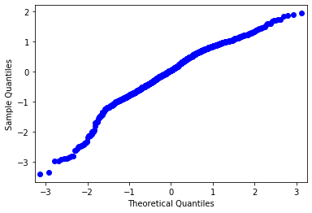

```python
residuals_mat21 = res_mat21.resid # residuals
fig = sm.qqplot(residuals_mat21)
plt.show()
```

```python
sns.heatmap(main_file[[
#     'bis2a_grade_pt',
#  'chem2a_grade_pt',
#  'mat16a_grade_pt',
 'mat21a_grade_pt',
'ATOG',
'ATOGA',
'ATOGB',
'ATOGC',
'ATOGD',
'ATOGE',
'ATOGF',
'ATOGG',
'APTAKEN',
'APPASSED',
'APCREDIT',
'GPA',
'LOWINCOME',
#'FG',
#'UNWEIGHTED_GPA',
'SAT_TOTAL_OFFICIAL',
'IS_URM',
'ANY_FIRST_TERM_MAJOR_IS_STEM',
'STARTED_INTERNATIONAL',
'FIRST_GENERATION',
'LOW_INCOME',
'TRIPLE',
#'NO_TRIPLE',
# 'AP_Bio',
#  'AP_CS',
#  'AP_Chemistry',
#  'AP_Calculus_AB',
#  'AP_Calculus_BC',
#  'AP_Physics_1',
#  'AP_Physics_2',
#  'AP_Physics_B',
#  'AP_Physics_C_EM',
#  'AP_Physics_C_Mech',
#  'AP_Stats',
 'AP_Bio_bool',
 'AP_CS_bool',
 'AP_Chemistry_bool',
 'AP_Calculus_AB_bool',
 'AP_Calculus_BC_bool',
#  'AP_Physics_1_bool',
#  'AP_Physics_2_bool',
#  'AP_Physics_B_bool',
#  'AP_AP_Physics_C_EM_bool',
 'AP_Physics_bool',
 'AP_Stats_bool',
 'SEX_F']].corr())
```

[output not shown]

```python
main_file[controls].isnull().sum()
main_file.describe()
```

|  | PIDM | TERM | CRAP | CRAPOLD | HSCODE | LSTYPE | ATOG | ATOGA | ATOGB | ATOGC | ... | AP_Calculus_BC_bool | AP_Physics_1_bool | AP_Physics_2_bool | AP_Physics_B_bool | AP_Physics_C_EM_bool | AP_Physics_C_Mech_bool | AP_Stats_bool | SEX_F | SEX_M | SEX_N |
| --- | --- | --- | --- | --- | --- | --- | --- | --- | --- | --- | --- | --- | --- | --- | --- | --- | --- | --- | --- | --- | --- |
| count | 2.399300e+04 | 23993.000000 | 0.0 | 0.0 | 23983.000000 | 23993.000000 | 23993.000000 | 23993.00000 | 23993.000000 | 23993.000000 | ... | 23993.000000 | 23993.000000 | 23993.000000 | 23993.000000 | 23993.000000 | 23993.000000 | 23993.000000 | 23993.000000 | 23993.000000 | 23993.000000 |
| mean | 3.273453e+06 | 201762.312716 | NaN | NaN | 174395.308302 | 1.167507 | 51.490447 | 7.25149 | 8.517734 | 11.270079 | ... | 0.007210 | 0.005502 | 0.000917 | 0.000417 | 0.000542 | 0.001625 | 0.004418 | 0.634477 | 0.362981 | 0.002542 |
| std | 1.246689e+05 | 110.760618 | NaN | NaN | 273621.973418 | 0.388211 | 11.507415 | 3.64118 | 2.052259 | 3.547796 | ... | 0.084609 | 0.073970 | 0.030268 | 0.020412 | 0.023271 | 0.040285 | 0.066322 | 0.481587 | 0.480869 | 0.050359 |
| min | 2.455146e+06 | 201610.000000 | NaN | NaN | 10806.000000 | 1.000000 | 0.000000 | 0.00000 | 0.000000 | 0.000000 | ... | 0.000000 | 0.000000 | 0.000000 | 0.000000 | 0.000000 | 0.000000 | 0.000000 | 0.000000 | 0.000000 | 0.000000 |
| 25% | 3.177790e+06 | 201710.000000 | NaN | NaN | 51412.000000 | 1.000000 | 45.000000 | 5.00000 | 8.000000 | 10.000000 | ... | 0.000000 | 0.000000 | 0.000000 | 0.000000 | 0.000000 | 0.000000 | 0.000000 | 0.000000 | 0.000000 | 0.000000 |
| 50% | 3.284463e+06 | 201810.000000 | NaN | NaN | 52980.000000 | 1.000000 | 49.000000 | 6.00000 | 8.000000 | 10.000000 | ... | 0.000000 | 0.000000 | 0.000000 | 0.000000 | 0.000000 | 0.000000 | 0.000000 | 1.000000 | 0.000000 | 0.000000 |
| 75% | 3.374587e+06 | 201810.000000 | NaN | NaN | 54284.000000 | 1.000000 | 54.000000 | 8.00000 | 8.000000 | 12.000000 | ... | 0.000000 | 0.000000 | 0.000000 | 0.000000 | 0.000000 | 0.000000 | 0.000000 | 1.000000 | 1.000000 | 0.000000 |
| max | 3.502799e+06 | 201910.000000 | NaN | NaN | 999999.000000 | 7.000000 | 240.000000 | 64.00000 | 50.000000 | 99.000000 | ... | 1.000000 | 1.000000 | 1.000000 | 1.000000 | 1.000000 | 1.000000 | 1.000000 | 1.000000 | 1.000000 | 1.000000 |

8 rows × 146 columns